# Sample comparison Broad vs LSP

The code for this report is on github [here](https://github.com/hbc/rubin-cell-fate-conversion).

```r
> library(useful)
> library(readr)
> library(dplyr)
> library(tidyr)
> library(ggplot2)
> library(stringr)
```

Read in the data for each plate into one big dataframe, make unique IDs for each batch/well combination and use those IDs as the column names.

```r
> setwd("~/rubin-cell-fate-conversion")
>
> # Creating a function to organize the data
> plate_reader = function(fn) {
+     batch = strsplit(basename(fn), ".", fixed = TRUE)[[1]][1]
+     data = read.table(fn, header = TRUE, row.names = 1)
+     colnames(data) = paste(batch, colnames(data), sep = "_")
+     data
+ }
> plates_fns = sort(list.files("data", pattern = "\\.dat", full.names = TRUE))
> plates = do.call(cbind, lapply(plates_fns, plate_reader))
> save(plates, file = "plates.RData")
```

```r
> load("plates.RData")
```

Create a dataframe of the metadata about each sample. This has an identifier for a sample, Which well it came from, which batch and what it was treated with.

```r
> welldata_fn = "metadata/Compound Layout 384w1B.csv"
> welldata = read_csv(welldata_fn) %>% gather(column, treatment, -row) %>% mutate(well = paste(row,
+     column, sep = "")) %>% dplyr::select(well, treatment)
> identities = data.frame(str_split_fixed(colnames(plates), "_", 3))
> colnames(identities) = c("batch", "drop", "well")
> identities$id = colnames(plates)
> welldata = identities %>% dplyr::select(batch, well) %>% left_join(welldata,
+     by = "well")
> rownames(welldata) = colnames(plates)
> welldata$sample = colnames(plates)
```

Verify that the samples match up between the read counts and the metadata dataframe and make sure there are no NA counts.

```r
> dim(welldata)
```

```
[1] 2688    4
```

```r
> dim(plates)
```

```
[1] 23481  2688
```

```r
> table(rownames(welldata) %in% colnames(plates))
```

```
TRUE
2688
```

```r
> corner(plates)
```

```
              M1_T384s1_A1 M1_T384s1_A2 M1_T384s1_A3 M1_T384s1_A4
0610005C13Rik            0            0            0            0
0610007N19Rik            2            5            2           12
0610007P14Rik            1            4            0           14
0610008F07Rik            0            0            0            0
0610009B14Rik            0            0            0            0
              M1_T384s1_A5
0610005C13Rik            0
0610007N19Rik            9
0610007P14Rik            8
0610008F07Rik            0
0610009B14Rik            0
```

```r
> corner(welldata)
```

```
             batch well treatment       sample
M1_T384s1_A1    M1   A1      SC 1 M1_T384s1_A1
M1_T384s1_A2    M1   A2      DMSO M1_T384s1_A2
M1_T384s1_A3    M1   A3        A3 M1_T384s1_A3
M1_T384s1_A4    M1   A4        A4 M1_T384s1_A4
M1_T384s1_A5    M1   A5        A5 M1_T384s1_A5
```

```r
> table(complete.cases(plates))
```

```
 TRUE
23481
```

Looks like we are good to go. While we’re at it we will load the positive control data.

```r
> positive_fn = "data/Feo_positive_controls.unq.refseq.umi.SC_and_Myoblast_Raw.txt"
> positive = read.table(positive_fn, header = TRUE, row.names = rownames(plates))
> positive$id = NULL
> positive_samples = data.frame(str_split_fixed(colnames(positive), "_", 3))
> identities = data.frame(str_split_fixed(colnames(plates), "_", 3))$X1
> positive_welldata = data.frame(batch = positive_samples$X1, treatment = positive_samples$X1,
+     well = positive_samples$X1)
```

Now we will calculate some summary statistics about each sample.

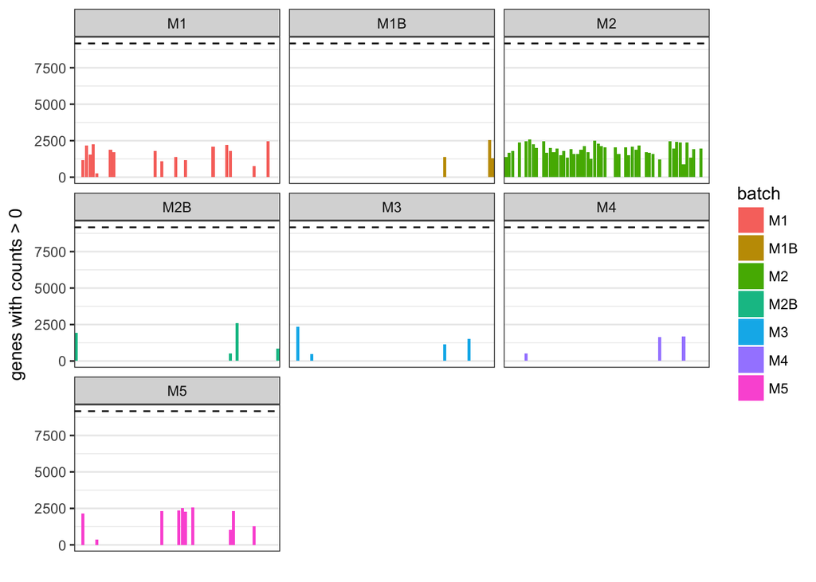

```r
> welldata$genes_detected = colSums(plates > 0)
> welldata$genes_detected_zscore = ave(welldata$genes_detected, FUN = scale)
> welldata$genes_detected_pval = 2 * pnorm(-abs(welldata$genes_detected_zscore))
> welldata$genes_detected_padj = p.adjust(welldata$genes_detected_pval, method = "BH")
> outliers = subset(welldata, genes_detected_padj < 0.1)
> ggplot(outliers, aes(treatment, genes_detected, fill = batch)) + geom_bar(stat = "identity",
+     position = "dodge") + facet_wrap(~batch) + geom_hline(yintercept = ave(welldata$genes_detected),
+     linetype = "dashed") + ylab("genes with counts > 0") + xlab("") + theme_bw() +
+     scale_x_discrete(breaks = NULL)
```

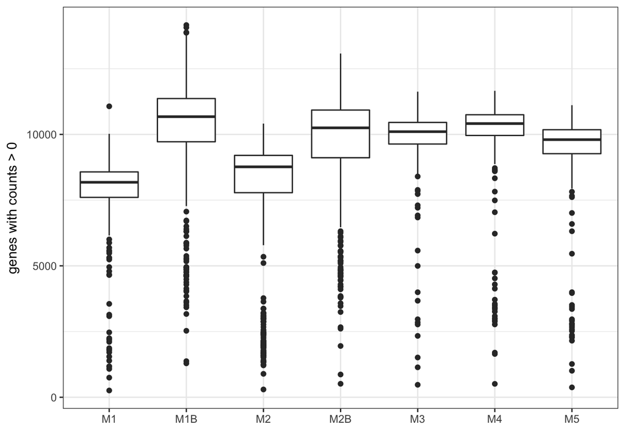

```r
> ggplot(welldata, aes(batch, genes_detected)) + geom_boxplot() + ylab("genes with counts > 0") +
+     xlab("") + theme_bw()
```

We can see it in the boxplot.

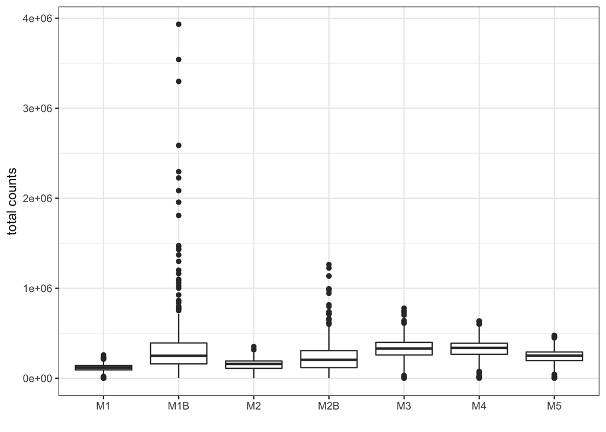

```r
> welldata$counts = colSums(plates)
> ggplot(welldata, aes(batch, counts)) + geom_boxplot() + ylab("total counts") +
+     xlab("") + theme_bw()
```

And the number of failed wells, where we call a well failed if it had < 10,000 total counts.

```r
> welldata$failed = colSums(plates) < 10000
> welldata %>% group_by(batch) %>% summarise(nfailed = sum(failed))
```

```
# A tibble: 7 × 2
   batch nfailed
  <fctr>   <int>
1     M1      16
2    M1B       4
3     M2      56
4    M2B       5
5     M3       7
6     M4       6
7     M5      16
```

We can also see in an estimate of library complexity that the M2 library is less complex than the other libraries.

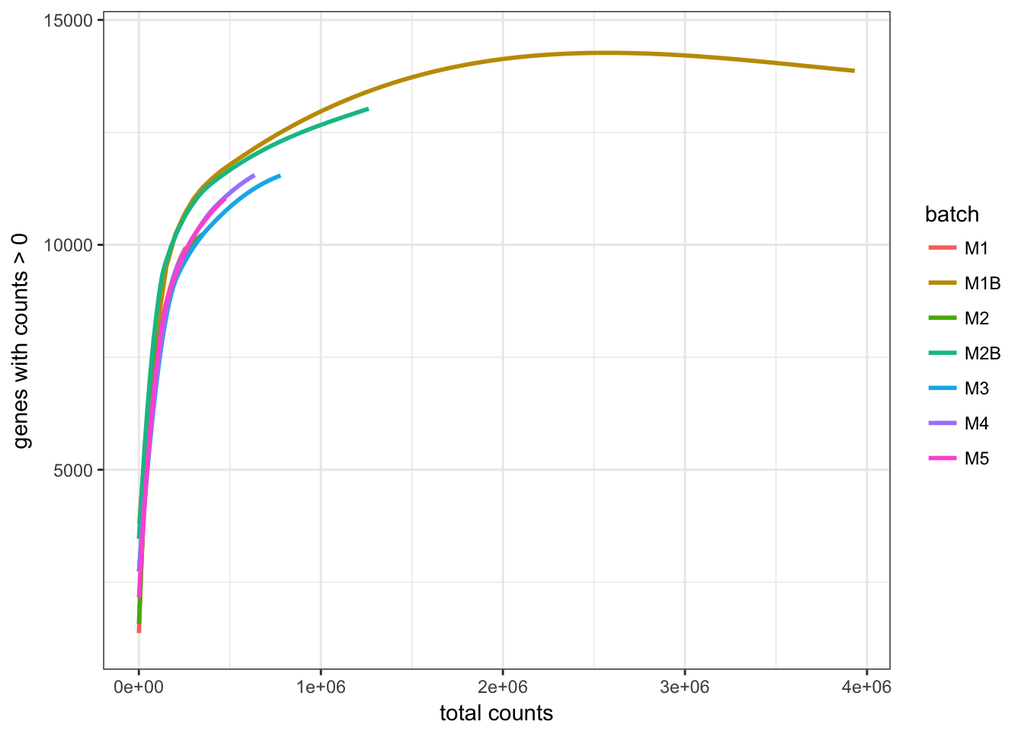

```r
> ggplot(welldata, aes(counts, genes_detected, color = batch)) + geom_smooth(fill = NA) +
+     ylab("genes with counts > 0") + xlab("total counts") + theme_bw()
```

# Render HTML file of .rmd

library(rmarkdown) render(“Screenseq1B_analysis.Rmd”)